# BKM-Analytics

Cemal

6 Mart 2019

In this document, we parse BKM web site for monthly transactions by transaction type and analyze the data for January 2017.

## Getting raw data from BKM web page

```r
raw_html <- read_html("https://bkm.com.tr/secilen-aya-ait-sektorel-gelisim/?filter_year=2017&filter_month=1&List=Listele")
raw_html
```

```
## {xml_document}
## <html lang="tr-TR">
## [1] <head>\n<meta http-equiv="Content-Type" content="text/html; charset= ...
## [2] <body>\n    <div id="anaKapsul">\n                <table width="735" ...
```

## Processing of raw data

```r
tables_list <- raw_html %>% html_table(fill=TRUE)
tables_list
```

[output not shown]

[output cut: 92 more lines]

```r
df_raw <- tables_list[[4]]
df_raw <- df_raw %>% slice(-(1:2))
colnames(df_raw)
```

```
## [1] "X1" "X2" "X3" "X4" "X5"
```

```r
colnames(df_raw) <- c("type", "txn_cc","txn_dc", "tl_cc","tl_dc")
df_raw %>% filter(type != "TOPLAM") %>% mutate_at(vars(txn_cc:tl_dc),funs(gsub("\\.","",.))) %>% mutate_at(vars(txn_cc:tl_dc),funs(gsub(",",".",.))) %>% tbl_df()
```

```
## # A tibble: 26 x 5
##    type                                   txn_cc   txn_dc   tl_cc   tl_dc
##    <chr>                                  <chr>    <chr>    <chr>   <chr>
##  1 ARABA KİRALAMA                         234458   29881    116.02  5.24
##  2 ARAÇ KİRALAMA-SATIŞ/SERVİS/YEDEK PARÇA 2693110  433196   1601.78 76.65
##  3 BENZİN VE YAKIT İSTASYONLARI           22457882 6460535  3861.49 427.61
##  4 BIREYSEL EMEKLILIK                     2568154  508      607.99  0.17
##  5 ÇEŞİTLİ GIDA                           20568348 10214579 3142.49 354.55
##  6 DOĞRUDAN PAZARLAMA                     425443   34240    113.06  2.92
##  7 EĞİTİM / KIRTASİYE / OFİS MALZEMELERİ  4772413  1855520  1198.04 108.68
##  8 ELEKTRİK-ELEKTRONİK EŞYA, BİLGİSAYAR   6633372  1140438  2536.99 202.96
##  9 GİYİM VE AKSESUAR                      26155139 7640918  3245.08 625.81
## 10 HAVAYOLLARI                            2083535  218903   798.56  128.85
## # ... with 16 more rows
```

```r
card_df <- df_raw %>% filter(type != "TOPLAM") %>% mutate_at(vars(txn_cc:tl_dc),funs(gsub("\\.","",.))) %>% mutate_at(vars(txn_cc:tl_dc),funs(as.numeric(gsub(",",".",.)))) %>% tbl_df()
card_df
```

```
## # A tibble: 26 x 5
##    type                                     txn_cc   txn_dc tl_cc  tl_dc
##    <chr>                                     <dbl>    <dbl> <dbl>  <dbl>
##  1 ARABA KİRALAMA                           234458    29881  116.   5.24
##  2 ARAÇ KİRALAMA-SATIŞ/SERVİS/YEDEK PARÇA  2693110   433196 1602.  76.6
##  3 BENZİN VE YAKIT İSTASYONLARI           22457882  6460535 3861. 428.
##  4 BIREYSEL EMEKLILIK                      2568154      508  608.   0.17
##  5 ÇEŞİTLİ GIDA                           20568348 10214579 3142. 355.
##  6 DOĞRUDAN PAZARLAMA                       425443    34240  113.   2.92
##  7 EĞİTİM / KIRTASİYE / OFİS MALZEMELERİ   4772413  1855520 1198. 109.
##  8 ELEKTRİK-ELEKTRONİK EŞYA, BİLGİSAYAR    6633372  1140438 2537. 203.
##  9 GİYİM VE AKSESUAR                      26155139  7640918 3245. 626.
## 10 HAVAYOLLARI                             2083535   218903  799. 129.
## # ... with 16 more rows
```

# Analysis

## Top 5 Transaction types by number of credit card transactions

```r
#### Top 5 TRANSACTIONS BY CC
card_df %>% arrange(desc(txn_cc)) %>% slice(1:5) %>% knitr::kable()
```

| type | txn_cc | txn_dc | tl_cc | tl_dc |
| --- | --- | --- | --- | --- |
| MARKET VE ALIŞVERİŞ MERKEZLERİ | 78792184 | 34615321 | 8272.22 | 1165.52 |
| YEMEK | 26336314 | 19935250 | 1393.97 | 497.84 |
| GİYİM VE AKSESUAR | 26155139 | 7640918 | 3245.08 | 625.81 |
| BENZİN VE YAKIT İSTASYONLARI | 22457882 | 6460535 | 3861.49 | 427.61 |
| ÇEŞİTLİ GIDA | 20568348 | 10214579 | 3142.49 | 354.55 |

## Top 5 Transaction types bY unit cost of purchase by credit card

```r
#### TOP 5 TYPES BY UNIT CREDIT CARD TRANSACTION COST
card_df %>% mutate(tl_cc_unit=tl_cc*10^6/txn_cc) %>% arrange(desc(tl_cc_unit)) %>% slice(1:5) %>% select(type,tl_cc_unit) %>% knitr::kable()
```

| type | tl_cc_unit |
| --- | --- |
| MÜTEAHHİT İŞLERİ | 898.5797 |
| KUYUMCULAR | 789.7719 |
| ARAÇ KİRALAMA-SATIŞ/SERVİS/YEDEK PARÇA | 594.7696 |
| YAPI MALZEMELERİ, HIRDAVAT, NALBURİYE | 578.0483 |
| KONAKLAMA | 497.1377 |

## Bar chart of transactions by credit card

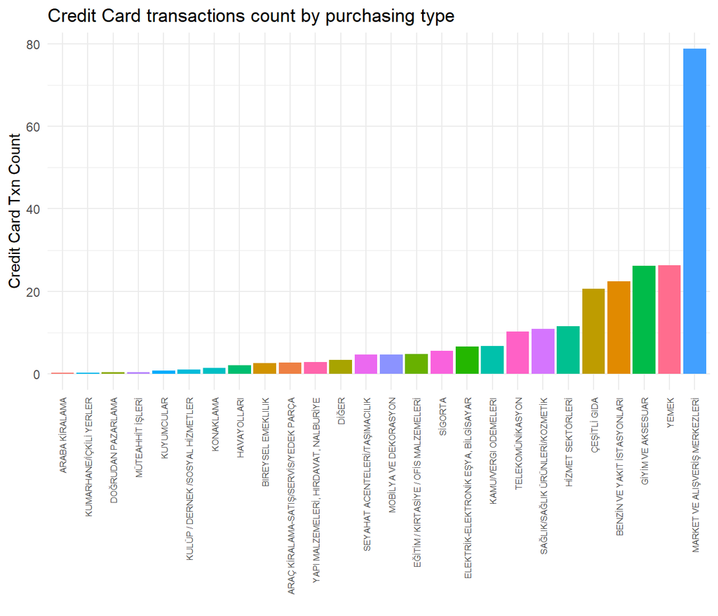

```r
ggplot(card_df, aes(x=reorder(type,txn_cc),y=txn_cc/10^6,fill=type)) +
  geom_bar(stat="identity") +
  theme_minimal() +
  theme(axis.text.x = element_text(angle = 90,hjust = 1,vjust = 0.5,size = 6),legend.position = "none") +
  labs(x="",y="Credit Card Txn Count", title="Credit Card transactions count by purchasing type")
```

## Bar chart of transactions by credit card cost

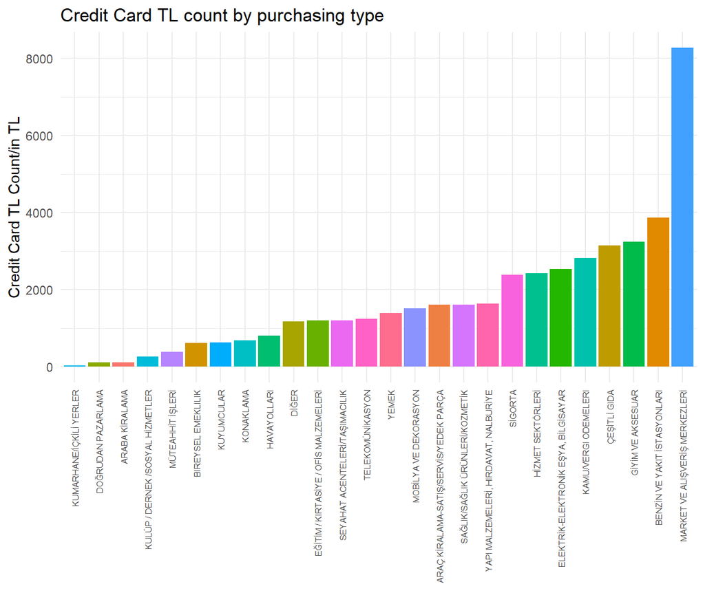

```r
ggplot(card_df, aes(x=reorder(type,tl_cc),y=tl_cc,fill=type)) +
  geom_bar(stat="identity") +
  theme_minimal() +
  theme(axis.text.x = element_text(angle = 90,hjust = 1,vjust = 0.5,size = 6),legend.position = "none") +
  labs(x="",y="Credit Card TL Count/in TL", title="Credit Card TL count by purchasing type")
```

## Bar chart of transactions by credit card unit cost

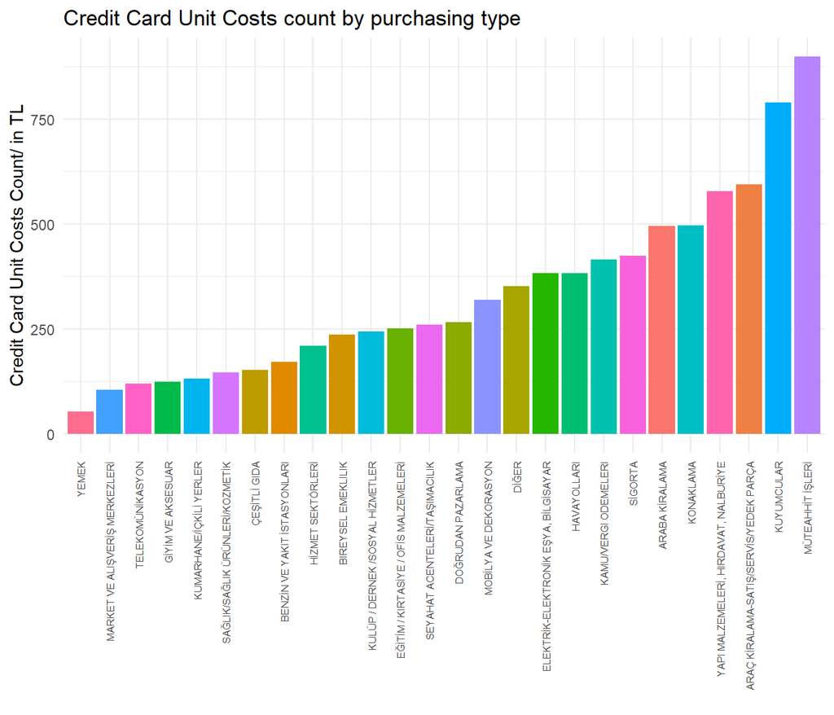

```r
ggplot(card_df, aes(x=reorder(type,(tl_cc_unit=tl_cc*10^6/txn_cc)),y=(tl_cc_unit=tl_cc*10^6/txn_cc),fill=type)) +
  geom_bar(stat="identity") +
  theme_minimal() +
  theme(axis.text.x = element_text(angle = 90,hjust = 1,vjust = 0.5,size = 6),legend.position = "none") +
  labs(x="",y="Credit Card Unit Costs Count/ in TL", title="Credit Card Unit Costs count by purchasing type")
```

## Bar chart of transactions by debit card

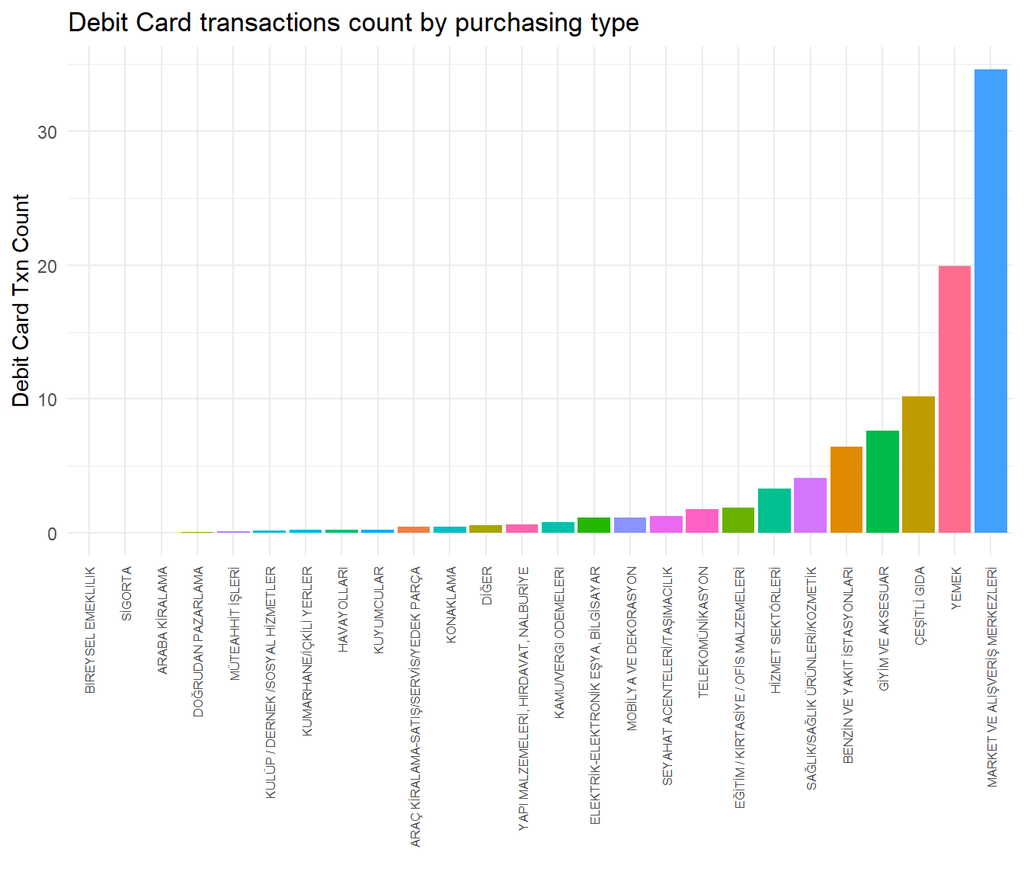

```r
ggplot(card_df, aes(x=reorder(type,txn_dc),y=txn_dc/10^6,fill=type)) +
  geom_bar(stat="identity") +
  theme_minimal() +
  theme(axis.text.x = element_text(angle = 90,hjust = 1,vjust = 0.5,size = 6),legend.position = "none") +
  labs(x="",y="Debit Card Txn Count", title="Debit Card transactions count by purchasing type")
```

## Bar chart of transactions by debit card cost

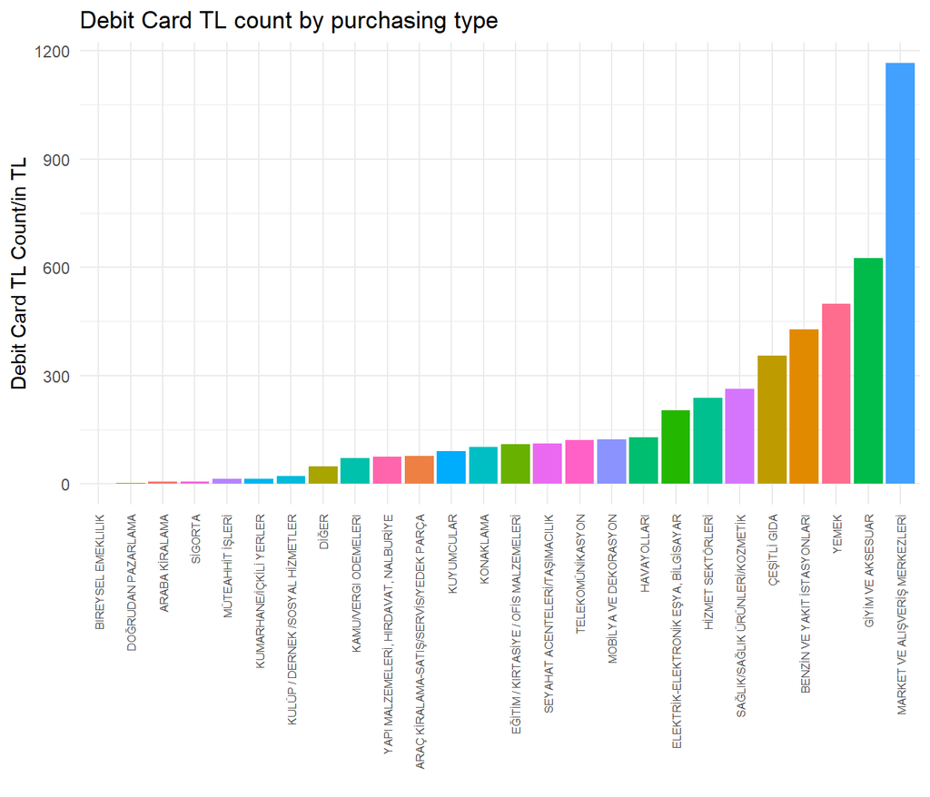

```r
ggplot(card_df, aes(x=reorder(type,tl_dc),y=tl_dc,fill=type)) +
  geom_bar(stat="identity") +
  theme_minimal() +
  theme(axis.text.x = element_text(angle = 90,hjust = 1,vjust = 0.5,size = 6),legend.position = "none") +
  labs(x="",y="Debit Card TL Count/in TL", title="Debit Card TL count by purchasing type")
```

## Bar chart of transactions by debit card unit cost

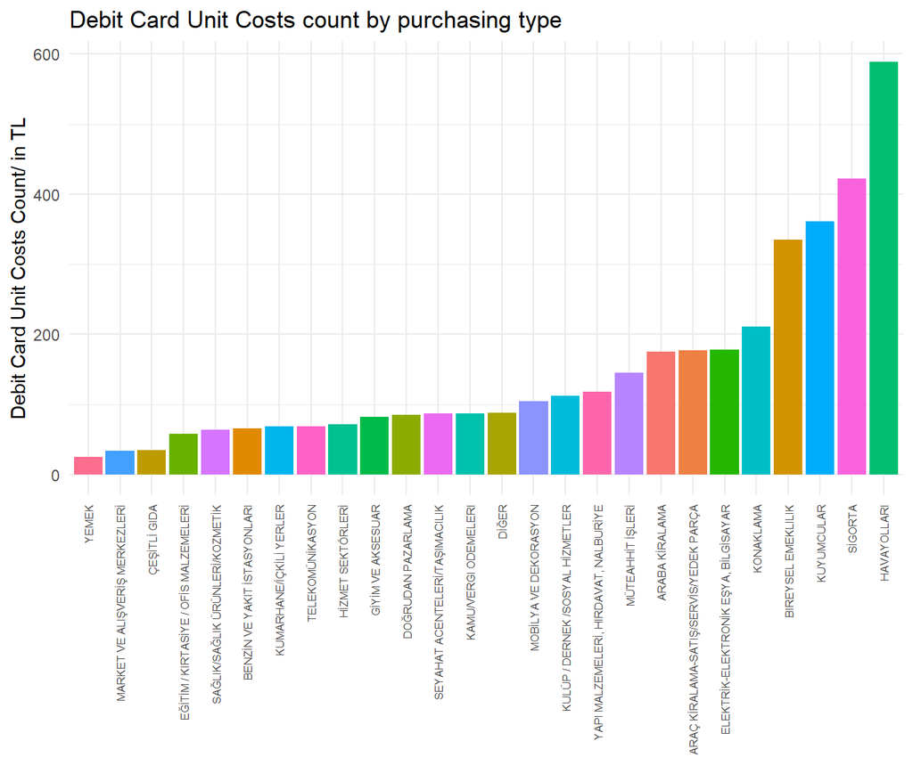

```r
ggplot(card_df, aes(x=reorder(type,(tl_dc_unit=tl_dc*10^6/txn_dc)),y=(tl_dc_unit=tl_dc*10^6/txn_dc),fill=type)) +
  geom_bar(stat="identity") +
  theme_minimal() +
  theme(axis.text.x = element_text(angle = 90,hjust = 1,vjust = 0.5,size = 6),legend.position = "none") +
  labs(x="",y="Debit Card Unit Costs Count/ in TL", title="Debit Card Unit Costs count by purchasing type")
```

## Top 5 Transaction types by number of debit card transactions

```r
#### Top 5 TRANSACTIONS BY DC
card_df %>% arrange(desc(txn_dc)) %>% slice(1:5) %>% select(type,txn_dc) %>% knitr::kable()
```

| type | txn_dc |
| --- | --- |
| MARKET VE ALIŞVERİŞ MERKEZLERİ | 34615321 |
| YEMEK | 19935250 |
| ÇEŞİTLİ GIDA | 10214579 |
| GİYİM VE AKSESUAR | 7640918 |
| BENZİN VE YAKIT İSTASYONLARI | 6460535 |

## Top 5 Transaction types bY unit cost of purchase by debit card

```r
#### TOP 5 TYPES BY UNIT CREDIT CARD TRANSACTION COST
card_df %>% mutate(tl_dc_unit=tl_dc*10^6/txn_dc) %>% arrange(desc(tl_dc_unit)) %>% slice(1:5) %>% select(type,tl_dc_unit) %>% knitr::kable()
```

| type | tl_dc_unit |
| --- | --- |
| HAVAYOLLARI | 588.6169 |
| SİGORTA | 422.0656 |
| KUYUMCULAR | 360.8923 |
| BIREYSEL EMEKLILIK | 334.6457 |
| KONAKLAMA | 210.9926 |

## Types where Credit Card transaction are higher than Debit Card

```r
card_df %>% mutate(txn_cc_higher = txn_cc > txn_dc) %>% select(type,txn_cc,txn_dc,txn_cc_higher)
```

```
## # A tibble: 26 x 4
##    type                                     txn_cc   txn_dc txn_cc_higher
##    <chr>                                     <dbl>    <dbl> <lgl>
##  1 ARABA KİRALAMA                           234458    29881 TRUE
##  2 ARAÇ KİRALAMA-SATIŞ/SERVİS/YEDEK PARÇA  2693110   433196 TRUE
##  3 BENZİN VE YAKIT İSTASYONLARI           22457882  6460535 TRUE
##  4 BIREYSEL EMEKLILIK                      2568154      508 TRUE
##  5 ÇEŞİTLİ GIDA                           20568348 10214579 TRUE
##  6 DOĞRUDAN PAZARLAMA                       425443    34240 TRUE
##  7 EĞİTİM / KIRTASİYE / OFİS MALZEMELERİ   4772413  1855520 TRUE
##  8 ELEKTRİK-ELEKTRONİK EŞYA, BİLGİSAYAR    6633372  1140438 TRUE
##  9 GİYİM VE AKSESUAR                      26155139  7640918 TRUE
## 10 HAVAYOLLARI                             2083535   218903 TRUE
## # ... with 16 more rows
```

## Types where Credit Card cost are higher than Debit Card

```r
card_df %>% mutate(tl_cc_higher = tl_cc > tl_dc) %>% select(type,tl_cc,tl_dc,tl_cc_higher)
```

```
## # A tibble: 26 x 4
##    type                                   tl_cc  tl_dc tl_cc_higher
##    <chr>                                  <dbl>  <dbl> <lgl>
##  1 ARABA KİRALAMA                          116.   5.24 TRUE
##  2 ARAÇ KİRALAMA-SATIŞ/SERVİS/YEDEK PARÇA 1602.  76.6  TRUE
##  3 BENZİN VE YAKIT İSTASYONLARI           3861. 428.   TRUE
##  4 BIREYSEL EMEKLILIK                      608.   0.17 TRUE
##  5 ÇEŞİTLİ GIDA                           3142. 355.   TRUE
##  6 DOĞRUDAN PAZARLAMA                      113.   2.92 TRUE
##  7 EĞİTİM / KIRTASİYE / OFİS MALZEMELERİ  1198. 109.   TRUE
##  8 ELEKTRİK-ELEKTRONİK EŞYA, BİLGİSAYAR   2537. 203.   TRUE
##  9 GİYİM VE AKSESUAR                      3245. 626.   TRUE
## 10 HAVAYOLLARI                             799. 129.   TRUE
## # ... with 16 more rows
```